# My Shiny Story

Matt Sharkey

8/6/2019

## From IT to Data Science

At my previous employer, I worked in IT operations as a Database Administrator. In March of 2018, a colleague on the Data Science team approached me about an internal job posting. His team was looking for a Data Engineer to support its data pipeline. I had already worked with the team on a IT project and fe support tickets, so I had an approximate idea of what skills they needed. I was about to graduate with a Masters in Analytics, and the opportunity seemed relevant. After thinking things over, I decided the best route forward was to take the job.

A team member resigned shortly after I signed on. I took on some of his projects, including the development of a web-app. I had barely changed my email signature before I started getting feature requests on the app. I couldn’t speak to the feasibility of the requests because I didn’t have experience in the application stack. In fact, I didn’t have much web-app experience in general as I’ve been a database specialist my entire career. After several discussions with stakeholders, I pressed the reset button.

## R you serious?

I decided to re-write the app using R with a SQL Server back-end. At that point, I had hundreds of hours of R coding experience from grad school and side projects. Also, most of my coworkers were Data Scientists and had strong R programming skills. If I had any gaps in my knowledge, they could help.

The Shiny package in R generates about 95% of the HTML, CSS, and JavaScript needed to build a web-app. For example, if I wanted “Hello World!” to appear in the browser, I would have needed to declare it inside of <h2> tags. However, with Shiny I called the h2() function.

```r
<h2>Hello World!</h2>
```

## Hello World!

```r
library(shiny)

h2('Hello World!')
```

## Hello World!

This code generates a date input control.

```r
dateRangeInput("date",
               strong("Date range"),
               start = "2007-01-01",
               end = "2017-07-31",
               min = "2007-01-01",
               max = "2017-07-31"
               )
```

Here’s the generated HTML.

```r
<div id="date">
<label class="control-label" for="date"> <strong>Date range</strong>
</label><div class="input-daterange input-group">
<input class="input-sm form-control" type="text"
data-date-week-start="0" data-date-format="yyyy-mm-dd"
data-date-start-view="month" data-min-date="2007-01-01"
data-max-date="2017-07-31"data-initial-date="2007-01-01"
data-date-autoclose="true"/><span class="input-group-addon">
to </span> <input  type="text" data-date-language="en"
data-date-week-start="0" data-date-format="yyyy-mm-dd"
data-min-date="2007-01-01" data-max-date="2017-07-31"/>
  </div></div>
```

## The Gameplan

My strategy was to push as much logic and data processing to the database as possible. I felt this was the best route because, again, most of my experience is on the database side. I also had concerns about R performance. R by default runs on one thread whereas SQL server by default can multi-thread.

I knew code generators were great for productivity but often at the cost of performance and functionality. It wasn’t clear to me how the app would handle database connections, application errors, or perform with multiple user sessions. As I progressed on the project, I learned a few techniques that put those concerns to rest. It’s my goal in this post to share those techniques.

## App Architecture

Before we can start discussing performance tuning, we must establish the basics. The main components of my Shiny app are UI, the Server object, and the database.

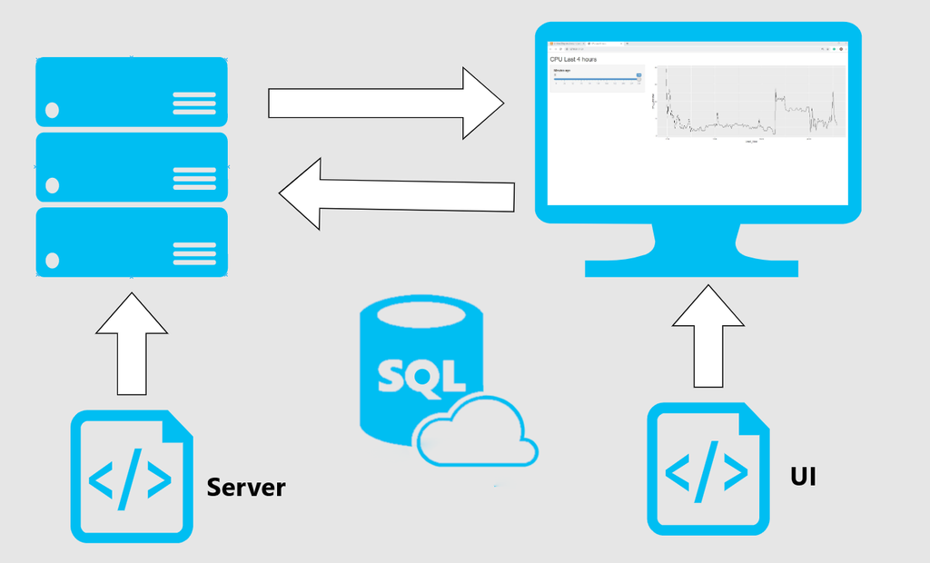

The code below provides the base components required for a Shiny database app. Multiple projects can use this template as a starting point.

```r
library(shiny)
library(DBI)
library(odbc)

con <- dbConnect(drv = odbc(),  Driver = 'Sql Server',Server = '.\\snapman',Database = 'Test')

my_ui <- fluidPage()

my_server <- function(input, output) {}

shinyApp(ui = my_ui, server = my_server)
```